# Supervised Learning - Foundations Project: ReCell

## Problem Statement

### Business Context

Buying and selling used phones and tablets used to be something that happened on a handful of online marketplace sites. But the used and refurbished device market has grown considerably over the past decade, and a new IDC (International Data Corporation) forecast predicts that the used phone market would be worth \$52.7bn by 2023 with a compound annual growth rate (CAGR) of 13.6% from 2018 to 2023. This growth can be attributed to an uptick in demand for used phones and tablets that offer considerable savings compared with new models.

Refurbished and used devices continue to provide cost-effective alternatives to both consumers and businesses that are looking to save money when purchasing one. There are plenty of other benefits associated with the used device market. Used and refurbished devices can be sold with warranties and can also be insured with proof of purchase. Third-party vendors/platforms, such as Verizon, Amazon, etc., provide attractive offers to customers for refurbished devices. Maximizing the longevity of devices through second-hand trade also reduces their environmental impact and helps in recycling and reducing waste. The impact of the COVID-19 outbreak may further boost this segment as consumers cut back on discretionary spending and buy phones and tablets only for immediate needs.

### Objective

The rising potential of this comparatively under-the-radar market fuels the need for an ML-based solution to develop a dynamic pricing strategy for used and refurbished devices. ReCell, a startup aiming to tap the potential in this market, has hired you as a data scientist. They want you to analyze the data provided and build a linear regression model to predict the price of a used phone/tablet and identify factors that significantly influence it.

### Data Description

The data contains the different attributes of used/refurbished phones and tablets. The data was collected in the year 2021. The detailed data dictionary is given below.

- brand_name: Name of manufacturing brand
- os: OS on which the device runs
- screen_size: Size of the screen in cm
- 4g: Whether 4G is available or not
- 5g: Whether 5G is available or not
- main_camera_mp: Resolution of the rear camera in megapixels
- selfie_camera_mp: Resolution of the front camera in megapixels
- int_memory: Amount of internal memory (ROM) in GB
- ram: Amount of RAM in GB
- battery: Energy capacity of the device battery in mAh
- weight: Weight of the device in grams
- release_year: Year when the device model was released
- days_used: Number of days the used/refurbished device has been used
- normalized_new_price: Normalized price of a new device of the same model in euros
- normalized_used_price: Normalized price of the used/refurbished device in euros

## Importing necessary libraries

```python
#reading and visualization
import numpy as np
import pandas as pd
import matplotlib.pyplot as plt
import seaborn as sns

sns.set()

# to split the data into train and test
from sklearn.model_selection import train_test_split

# to build linear regression_model
import statsmodels.api as sm

#for model performance
from sklearn.metrics import mean_absolute_error, mean_squared_error, r2_score

#to compute VIF
from statsmodels.stats.outliers_influence import variance_inflation_factor
```

## Loading the dataset

```python
#getting dataset from drive
from google.colab import drive
drive.mount('/content/drive')
```

```python
df = pd.read_csv('/content/drive/MyDrive/SupervisedLearning/used_device_data.csv')
```

## Data Overview

- Observations
- Sanity checks

```python
df.head()
```

|  | brand_name | os | screen_size | 4g | 5g | main_camera_mp | selfie_camera_mp | int_memory | ram | battery | weight | release_year | days_used | normalized_used_price | normalized_new_price |
| --- | --- | --- | --- | --- | --- | --- | --- | --- | --- | --- | --- | --- | --- | --- | --- |
| 0 | Honor | Android | 14.50 | yes | no | 13.0 | 5.0 | 64.0 | 3.0 | 3020.0 | 146.0 | 2020 | 127 | 4.307572 | 4.715100 |
| 1 | Honor | Android | 17.30 | yes | yes | 13.0 | 16.0 | 128.0 | 8.0 | 4300.0 | 213.0 | 2020 | 325 | 5.162097 | 5.519018 |
| 2 | Honor | Android | 16.69 | yes | yes | 13.0 | 8.0 | 128.0 | 8.0 | 4200.0 | 213.0 | 2020 | 162 | 5.111084 | 5.884631 |
| 3 | Honor | Android | 25.50 | yes | yes | 13.0 | 8.0 | 64.0 | 6.0 | 7250.0 | 480.0 | 2020 | 345 | 5.135387 | 5.630961 |
| 4 | Honor | Android | 15.32 | yes | no | 13.0 | 8.0 | 64.0 | 3.0 | 5000.0 | 185.0 | 2020 | 293 | 4.389995 | 4.947837 |

- Dataset contains information about different brand phones with their specifications. Dataset seems to have some missing entries.

```python
df.shape
```

```
(3454, 15)
```

- There are 3454 rows and 15 columns

```python
df.describe().T
```

|  | count | mean | std | min | 25% | 50% | 75% | max |
| --- | --- | --- | --- | --- | --- | --- | --- | --- |
| screen_size | 3454.0 | 13.713115 | 3.805280 | 5.080000 | 12.700000 | 12.830000 | 15.340000 | 30.710000 |
| main_camera_mp | 3275.0 | 9.460208 | 4.815461 | 0.080000 | 5.000000 | 8.000000 | 13.000000 | 48.000000 |
| selfie_camera_mp | 3452.0 | 6.554229 | 6.970372 | 0.000000 | 2.000000 | 5.000000 | 8.000000 | 32.000000 |
| int_memory | 3450.0 | 54.573099 | 84.972371 | 0.010000 | 16.000000 | 32.000000 | 64.000000 | 1024.000000 |
| ram | 3450.0 | 4.036122 | 1.365105 | 0.020000 | 4.000000 | 4.000000 | 4.000000 | 12.000000 |
| battery | 3448.0 | 3133.402697 | 1299.682844 | 500.000000 | 2100.000000 | 3000.000000 | 4000.000000 | 9720.000000 |
| weight | 3447.0 | 182.751871 | 88.413228 | 69.000000 | 142.000000 | 160.000000 | 185.000000 | 855.000000 |
| release_year | 3454.0 | 2015.965258 | 2.298455 | 2013.000000 | 2014.000000 | 2015.500000 | 2018.000000 | 2020.000000 |
| days_used | 3454.0 | 674.869716 | 248.580166 | 91.000000 | 533.500000 | 690.500000 | 868.750000 | 1094.000000 |
| normalized_used_price | 3454.0 | 4.364712 | 0.588914 | 1.536867 | 4.033931 | 4.405133 | 4.755700 | 6.619433 |
| normalized_new_price | 3454.0 | 5.233107 | 0.683637 | 2.901422 | 4.790342 | 5.245892 | 5.673718 | 7.847841 |

- The mean refurbished price for the phones is around 4.4 euros
- Maximum price is around 6.6 euros.
- Mean screen size is around 13.7

```python
df.info()
```

```
<class 'pandas.core.frame.DataFrame'>
RangeIndex: 3454 entries, 0 to 3453
Data columns (total 15 columns):
 #   Column                 Non-Null Count  Dtype
---  ------                 --------------  -----
 0   brand_name             3454 non-null   object
 1   os                     3454 non-null   object
 2   screen_size            3454 non-null   float64
 3   4g                     3454 non-null   object
 4   5g                     3454 non-null   object
 5   main_camera_mp         3275 non-null   float64
 6   selfie_camera_mp       3452 non-null   float64
 7   int_memory             3450 non-null   float64
 8   ram                    3450 non-null   float64
 9   battery                3448 non-null   float64
 10  weight                 3447 non-null   float64
 11  release_year           3454 non-null   int64
 12  days_used              3454 non-null   int64
 13  normalized_used_price  3454 non-null   float64
 14  normalized_new_price   3454 non-null   float64
dtypes: float64(9), int64(2), object(4)
memory usage: 404.9+ KB
```

- There are 11 numeric type columns and 4 object type columns.

```python
df.duplicated().sum()
```

```
0
```

- There are no duplicates values in the data

```python
df.isnull().sum()
```

```
brand_name                 0
os                         0
screen_size                0
4g                         0
5g                         0
main_camera_mp           179
selfie_camera_mp           2
int_memory                 4
ram                        4
battery                    6
weight                     7
release_year               0
days_used                  0
normalized_used_price      0
normalized_new_price       0
dtype: int64
```

- There are some missing values in a few columns

```python
#creating a copy of the data
dfc = df.copy()
```

## Exploratory Data Analysis (EDA)

- EDA is an important part of any project involving data.
- It is important to investigate and understand the data better before building a model with it.
- A few questions have been mentioned below which will help you approach the analysis in the right manner and generate insights from the data.
- A thorough analysis of the data, in addition to the questions mentioned below, should be done.

**Questions**:

1. What does the distribution of normalized used device prices look like?
2. What percentage of the used device market is dominated by Android devices?
3. The amount of RAM is important for the smooth functioning of a device. How does the amount of RAM vary with the brand?
4. A large battery often increases a device's weight, making it feel uncomfortable in the hands. How does the weight vary for phones and tablets offering large batteries (more than 4500 mAh)?
5. Bigger screens are desirable for entertainment purposes as they offer a better viewing experience. How many phones and tablets are available across different brands with a screen size larger than 6 inches?
6. A lot of devices nowadays offer great selfie cameras, allowing us to capture our favorite moments with loved ones. What is the distribution of devices offering greater than 8MP selfie cameras across brands?
7. Which attributes are highly correlated with the normalized price of a used device?

**Univariate Analysis**

**Brand name**

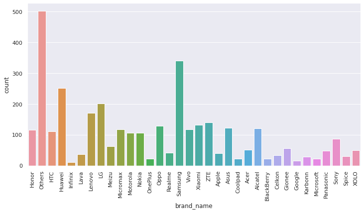

```python
plt.figure(figsize=(12,6))
sns.countplot(data=dfc, x='brand_name');
plt.xticks(rotation=90);
```

**os**

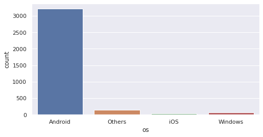

```python
plt.figure(figsize=(8,4))
sns.countplot(data=dfc, x='os');
```

- Almost 90% of the phones are Android

**4g**

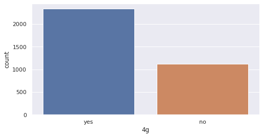

```python
plt.figure(figsize=(8,4))
sns.countplot(data=dfc, x='4g');
```

- Mostly 4g phones are up for re-sell.

**5g**

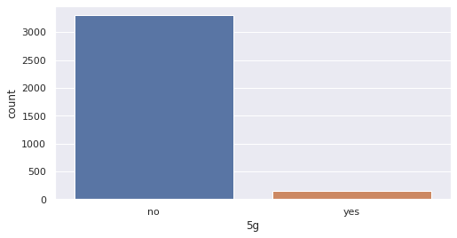

```python
plt.figure(figsize=(8,4))
sns.countplot(data=dfc, x='5g');
```

- Most of the phones doesn't support 5g network

**Release Year**

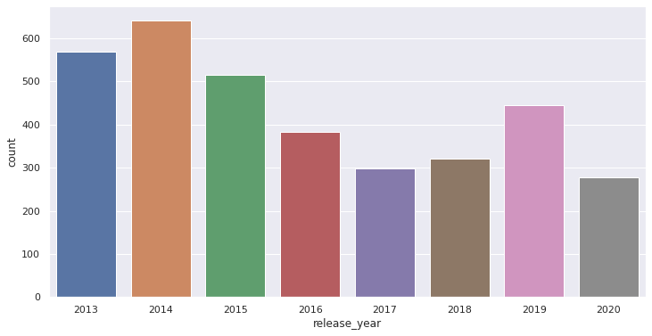

```python
plt.figure(figsize=(12,6))
sns.countplot(data=dfc, x='release_year');
```

- Maximum phones were released in 2014.

**Screen size**

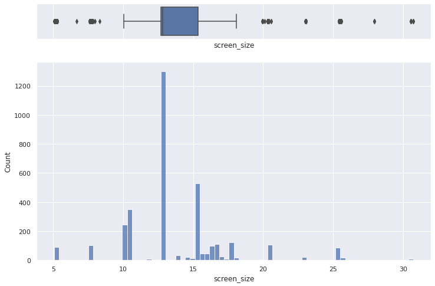

```python
# creating a figure composed of two matplotlib.Axes objects (ax_box and ax_hist)
f, (ax_box, ax_hist) = plt.subplots(2, sharex=True, gridspec_kw={"height_ratios": (.15, .85)}, figsize=(12,8))

# assigning a graph to each ax
sns.boxplot(data=dfc,x='screen_size', ax=ax_box);
sns.histplot(data=dfc, x='screen_size', ax=ax_hist);
```

**Main camera mp**

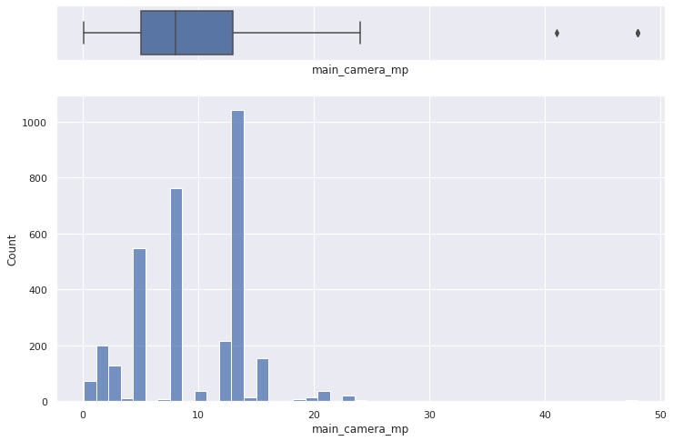

```python
f, (ax_box, ax_hist) = plt.subplots(2, sharex=True, gridspec_kw={"height_ratios": (.15, .85)}, figsize=(12,8))

# assigning a graph to each ax
sns.boxplot(data=dfc,x='main_camera_mp', ax=ax_box);
sns.histplot(data=dfc, x='main_camera_mp', ax=ax_hist);
```

**Selfie camera mp**

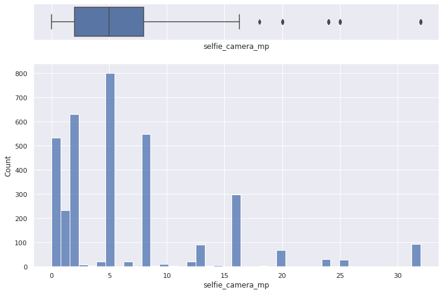

```python
f, (ax_box, ax_hist) = plt.subplots(2, sharex=True, gridspec_kw={"height_ratios": (.15, .85)}, figsize=(12,8))

# assigning a graph to each ax
sns.boxplot(data=dfc,x='selfie_camera_mp', ax=ax_box);
sns.histplot(data=dfc, x='selfie_camera_mp', ax=ax_hist);
```

- There are a few outliers with median being at 5

**Int_memory**

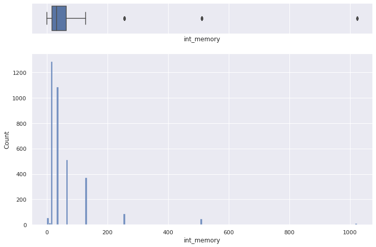

```python
f, (ax_box, ax_hist) = plt.subplots(2, sharex=True, gridspec_kw={"height_ratios": (.15, .85)}, figsize=(12,8))

# assigning a graph to each ax
sns.boxplot(data=dfc,x='int_memory', ax=ax_box);
sns.histplot(data=dfc, x='int_memory', ax=ax_hist);
```

- There are a few outliers in the data
- Median being at around 30

**Ram**

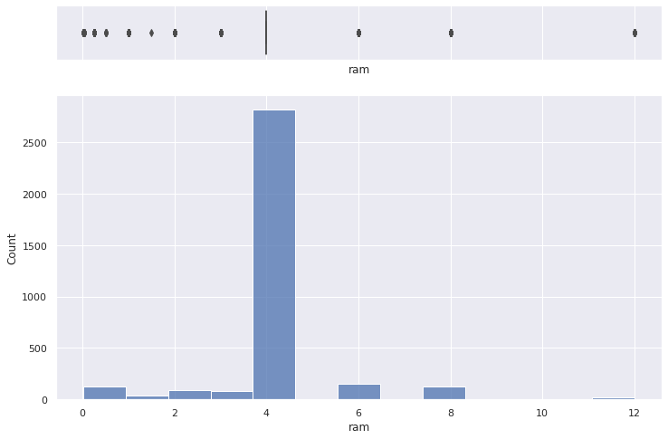

```python
f, (ax_box, ax_hist) = plt.subplots(2, sharex=True, gridspec_kw={"height_ratios": (.15, .85)}, figsize=(12,8))

# assigning a graph to each ax
sns.boxplot(data=dfc,x='ram', ax=ax_box);
sns.histplot(data=dfc, x='ram', ax=ax_hist);
```

- Most of the phones have RAM around 4 GB

**Battery**

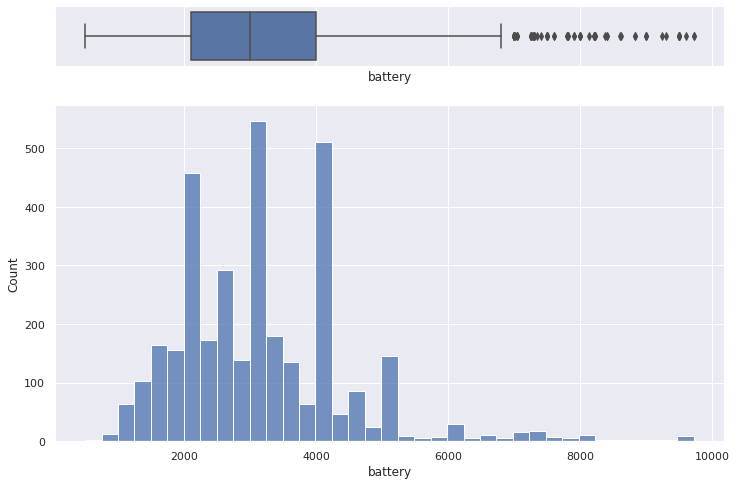

```python
f, (ax_box, ax_hist) = plt.subplots(2, sharex=True, gridspec_kw={"height_ratios": (.15, .85)}, figsize=(12,8))

# assigning a graph to each ax
sns.boxplot(data=dfc,x='battery', ax=ax_box);
sns.histplot(data=dfc, x='battery', ax=ax_hist);
```

- There are many outliers in the data with the median at around 3000

**Weight**

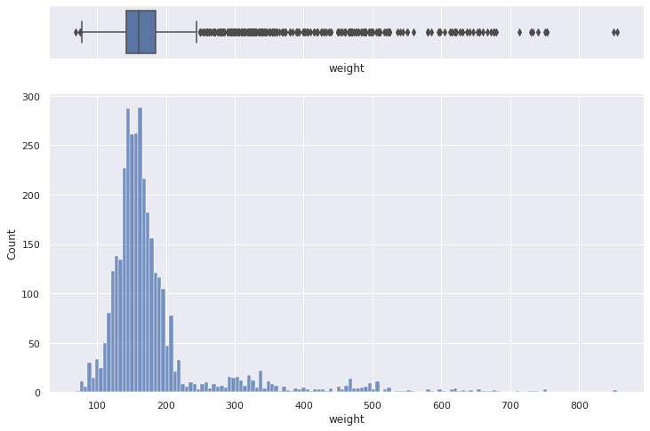

```python
f, (ax_box, ax_hist) = plt.subplots(2, sharex=True, gridspec_kw={"height_ratios": (.15, .85)}, figsize=(12,8))

# assigning a graph to each ax
sns.boxplot(data=dfc,x='weight', ax=ax_box);
sns.histplot(data=dfc, x='weight', ax=ax_hist);
```

- Weight of phones/tablet varies a lot hence there are many outliers. They cannot be treated as they are facts.

**Days Used**

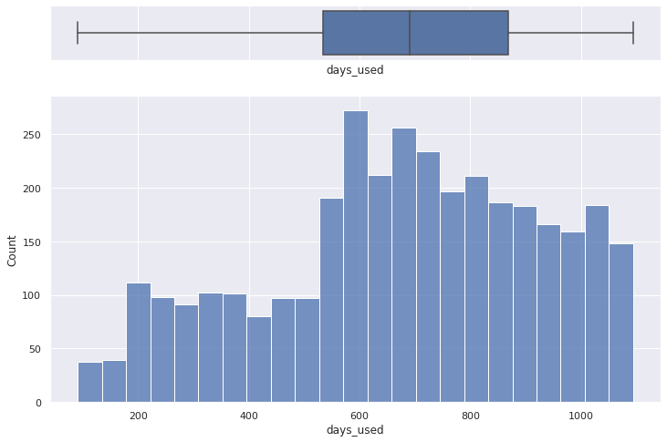

```python
f, (ax_box, ax_hist) = plt.subplots(2, sharex=True, gridspec_kw={"height_ratios": (.15, .85)}, figsize=(12,8))

# assigning a graph to each ax
sns.boxplot(data=dfc,x='days_used', ax=ax_box);
sns.histplot(data=dfc, x='days_used', ax=ax_hist);
```

- There are no outliers in the data and the median days used is around 700.

**Normalized new price**

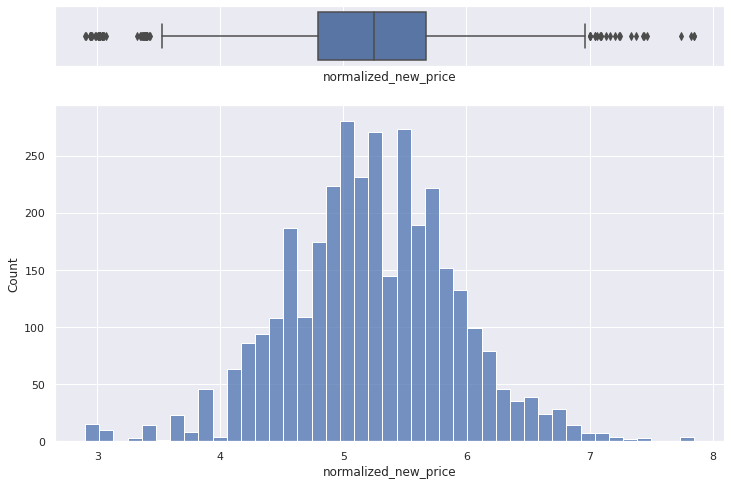

```python
f, (ax_box, ax_hist) = plt.subplots(2, sharex=True, gridspec_kw={"height_ratios": (.15, .85)}, figsize=(12,8))

# assigning a graph to each ax
sns.boxplot(data=dfc,x='normalized_new_price', ax=ax_box);
sns.histplot(data=dfc, x='normalized_new_price', ax=ax_hist);
```

- There are a few outliers with a median at around 5.2 and maximum at 7.8

**Normalized used price**

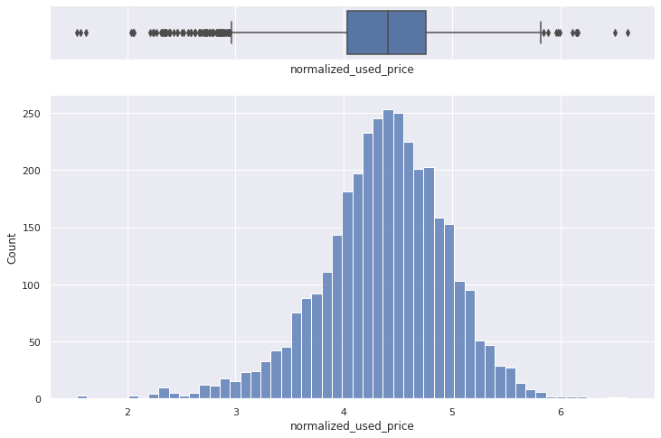

```python
f, (ax_box, ax_hist) = plt.subplots(2, sharex=True, gridspec_kw={"height_ratios": (.15, .85)}, figsize=(12,8))

# assigning a graph to each ax
sns.boxplot(data=dfc,x='normalized_used_price', ax=ax_box);
sns.histplot(data=dfc, x='normalized_used_price', ax=ax_hist);
```

- There are outliers in the data with a minimum at 1 and maximum at around 7.
- The median is at 4.4.

**Bivariate Analysis**

**Correlation check**

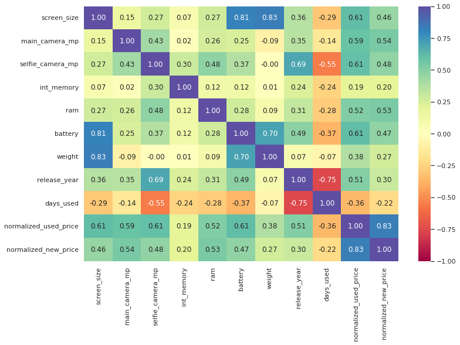

```python
#creating heatmap
plt.figure(figsize=(12,8))
sns.heatmap(dfc.corr(), annot=True, vmin=-1, vmax=1, fmt=".2f", cmap="Spectral")
plt.show()
```

- Screen size is highly correlated with weight of the device as bigger the screen size, bigger and heavier the deivce.
- Screen size is also highly correlated with battery as bigger battery size is required for bigger screen size.
- Weight and battery are also highly correlated.

**Brand name vs weight**

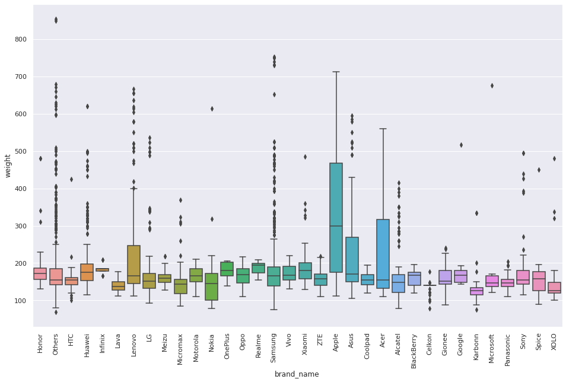

```python
#boxplot to check weight distribution for each brand
plt.figure(figsize=(16, 10))
sns.boxplot(data=dfc, x='brand_name', y='weight')
plt.xticks(rotation=90)
plt.show()
```

- Apple seems to have the maximum median weight of around 300.
- For rest of the brands median weight is less than 200.

**Brand name vs Screen size**

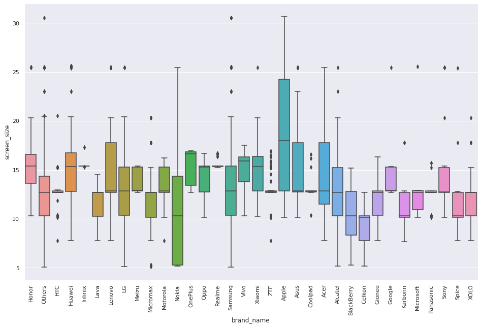

```python
#boxplot of screen size variation for different brands
plt.figure(figsize=(16, 10))
sns.boxplot(data=dfc, x='brand_name', y='screen_size')
plt.xticks(rotation=90)
plt.show()
```

- Apple has the highest median screen size of about 17.
- There are devices having screen size as low as 5 and maximnum going above 30.

**Brand name vs Main camera MP**

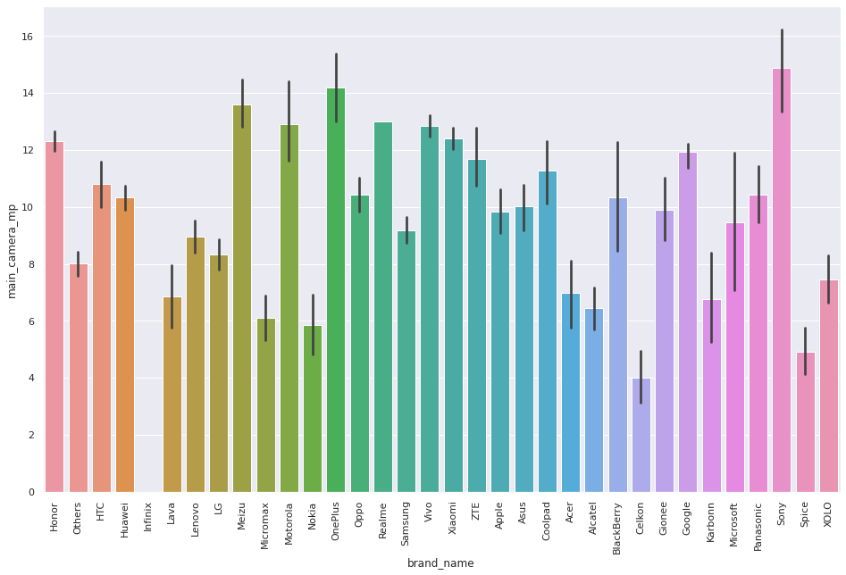

```python
plt.figure(figsize=(16, 10))
sns.barplot(data=dfc, x='brand_name', y='main_camera_mp')
plt.xticks(rotation=90)
plt.show()
```

- Sony devices has the highest main camera MP.
- Dataset doesn't have any information for Infinix devices.

**Brand Name and Selfie Camera MP**

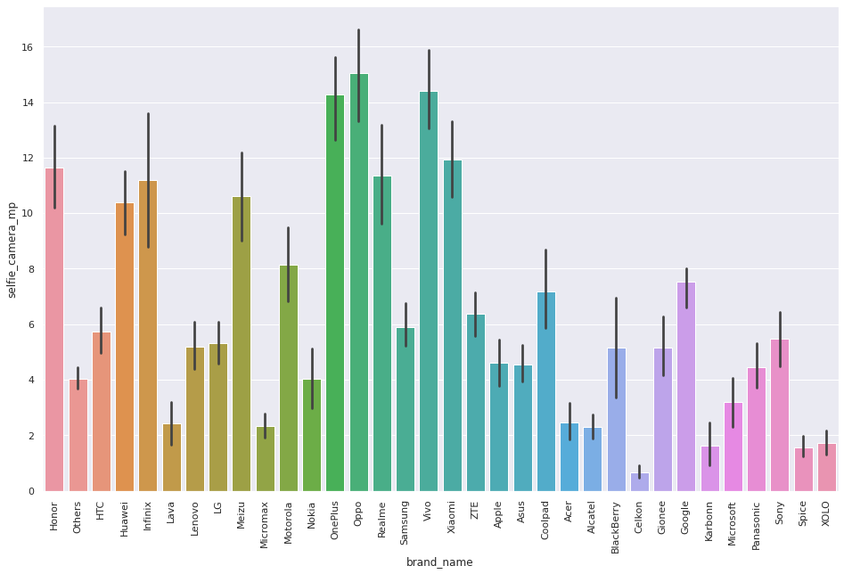

```python
plt.figure(figsize=(16, 10))
sns.barplot(data=dfc, x='brand_name', y='selfie_camera_mp')
plt.xticks(rotation=90)
plt.show()
```

- Oppo has the best selfie camera.

**Brand name vs ram**

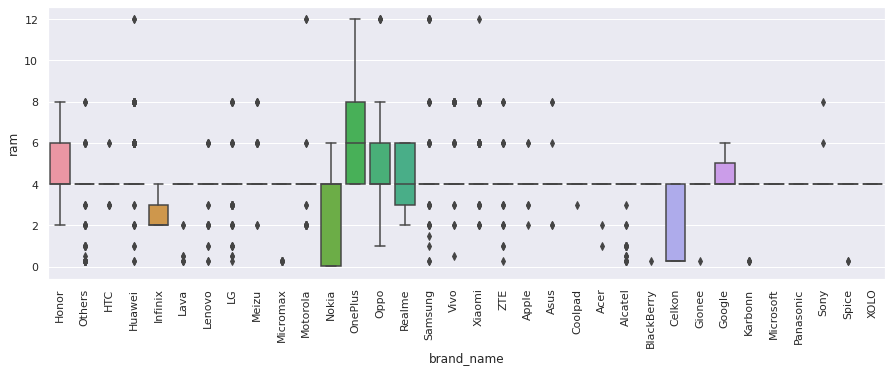

```python
plt.figure(figsize=(15, 5))
sns.boxplot(data=dfc, x="brand_name", y="ram");
plt.xticks(rotation=90);
```

- Almost all brands provide 4 GB of ram.
- Oneplus devices possess the highest ram amongst all.

**4g and normalized used price**

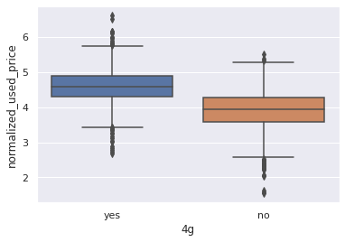

```python
sns.boxplot(data=dfc, x="4g", y="normalized_used_price");
```

- Most of the phones are 4g compatible and their median price is higher than the one without 4g.

**5g and normalized used price**

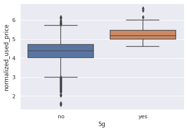

```python
sns.boxplot(data=dfc, x="5g", y="normalized_used_price");
```

- Devices supporting 5g network has their price higher than the others.

**Release Year and normalized used price**

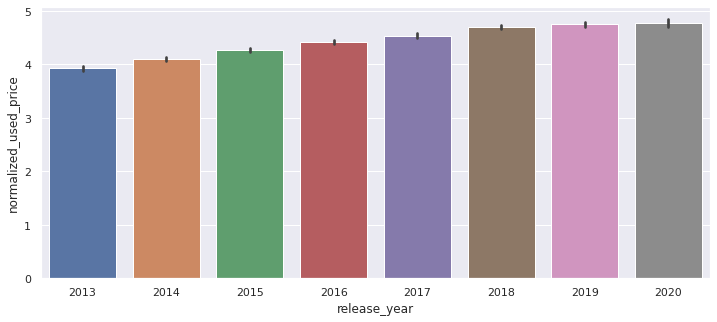

```python
plt.figure(figsize=(12, 5))
sns.barplot(data=dfc, x='release_year', y='normalized_used_price');
```

## Data Preprocessing

- Missing value treatment
- Feature engineering (if needed)
- Outlier detection and treatment (if needed)
- Preparing data for modeling
- Any other preprocessing steps (if needed)

**Missing Value Treatment**

```python
#creating a copy
dfc1 = dfc.copy()
```

```python
#checking for null values
dfc1.isnull().sum()
```

```
brand_name                 0
os                         0
screen_size                0
4g                         0
5g                         0
main_camera_mp           179
selfie_camera_mp           2
int_memory                 4
ram                        4
battery                    6
weight                     7
release_year               0
days_used                  0
normalized_used_price      0
normalized_new_price       0
dtype: int64
```

- As we can observe, we have 6 columns with missing values.
- We will fix the data with the median by grouping the data on brand name and release year.

```python
#imputing values
fill_cols = [
    "main_camera_mp",
    "selfie_camera_mp",
    "int_memory",
    "ram",
    "battery",
    "weight",]

for col in fill_cols:
  dfc1[col] = dfc1[col].fillna(value=dfc1.groupby(['release_year','brand_name'])[col].transform('median'))
```

```python
#checking again for missing values after imputing once
dfc1.isnull().sum()
```

```
brand_name                 0
os                         0
screen_size                0
4g                         0
5g                         0
main_camera_mp           179
selfie_camera_mp           2
int_memory                 0
ram                        0
battery                    6
weight                     7
release_year               0
days_used                  0
normalized_used_price      0
normalized_new_price       0
dtype: int64
```

- We still have 4 columns with missing values.
- We will fill the missing values with the median by grouping the data on brand name.

```python
#imputing values
fill_cols = [
    "main_camera_mp",
    "selfie_camera_mp",
    "battery",
    "weight",]

for col in fill_cols:
  dfc1[col] = dfc1[col].fillna(value=dfc1.groupby(['brand_name'])[col].transform('median'))
```

```python
#checking for missing values
dfc1.isnull().sum()
```

```
brand_name                0
os                        0
screen_size               0
4g                        0
5g                        0
main_camera_mp           10
selfie_camera_mp          0
int_memory                0
ram                       0
battery                   0
weight                    0
release_year              0
days_used                 0
normalized_used_price     0
normalized_new_price      0
dtype: int64
```

- As observed, except main_camera_mp, all the columns are treated for missing values.
- We will impute the missing value in main_camera_mp by the median for that column.

```python
#imputing values in main_camera_mp
dfc1['main_camera_mp'] = dfc1['main_camera_mp'].fillna(dfc1['main_camera_mp'].median())
```

```python
#checking for missing values
dfc1.isnull().sum()
```

```
brand_name               0
os                       0
screen_size              0
4g                       0
5g                       0
main_camera_mp           0
selfie_camera_mp         0
int_memory               0
ram                      0
battery                  0
weight                   0
release_year             0
days_used                0
normalized_used_price    0
normalized_new_price     0
dtype: int64
```

- There are no missing values.

**Feature Engineering**

- Let's create a new column 'years_running' by taking difference between last year in the data that is 2021 and the release year.
- We will drop the release year column as year themselves are not numerical in nature.

```python
dfc1["years_running"] = 2021 - dfc1["release_year"]
dfc1.drop("release_year", axis=1, inplace=True)
```

```python
dfc1
```

|  | brand_name | os | screen_size | 4g | 5g | main_camera_mp | selfie_camera_mp | int_memory | ram | battery | weight | days_used | normalized_used_price | normalized_new_price | years_running |
| --- | --- | --- | --- | --- | --- | --- | --- | --- | --- | --- | --- | --- | --- | --- | --- |
| 0 | Honor | Android | 14.50 | yes | no | 13.0 | 5.0 | 64.0 | 3.0 | 3020.0 | 146.0 | 127 | 4.307572 | 4.715100 | 1 |
| 1 | Honor | Android | 17.30 | yes | yes | 13.0 | 16.0 | 128.0 | 8.0 | 4300.0 | 213.0 | 325 | 5.162097 | 5.519018 | 1 |
| 2 | Honor | Android | 16.69 | yes | yes | 13.0 | 8.0 | 128.0 | 8.0 | 4200.0 | 213.0 | 162 | 5.111084 | 5.884631 | 1 |
| 3 | Honor | Android | 25.50 | yes | yes | 13.0 | 8.0 | 64.0 | 6.0 | 7250.0 | 480.0 | 345 | 5.135387 | 5.630961 | 1 |
| 4 | Honor | Android | 15.32 | yes | no | 13.0 | 8.0 | 64.0 | 3.0 | 5000.0 | 185.0 | 293 | 4.389995 | 4.947837 | 1 |
| ... | ... | ... | ... | ... | ... | ... | ... | ... | ... | ... | ... | ... | ... | ... | ... |
| 3449 | Asus | Android | 15.34 | yes | no | 13.0 | 8.0 | 64.0 | 6.0 | 5000.0 | 190.0 | 232 | 4.492337 | 6.483872 | 2 |
| 3450 | Asus | Android | 15.24 | yes | no | 13.0 | 8.0 | 128.0 | 8.0 | 4000.0 | 200.0 | 541 | 5.037732 | 6.251538 | 3 |
| 3451 | Alcatel | Android | 15.80 | yes | no | 13.0 | 5.0 | 32.0 | 3.0 | 4000.0 | 165.0 | 201 | 4.357350 | 4.528829 | 1 |
| 3452 | Alcatel | Android | 15.80 | yes | no | 13.0 | 5.0 | 32.0 | 2.0 | 4000.0 | 160.0 | 149 | 4.349762 | 4.624188 | 1 |
| 3453 | Alcatel | Android | 12.83 | yes | no | 13.0 | 5.0 | 16.0 | 2.0 | 4000.0 | 168.0 | 176 | 4.132122 | 4.279994 | 1 |

3454 rows × 15 columns

**Outliers Check**

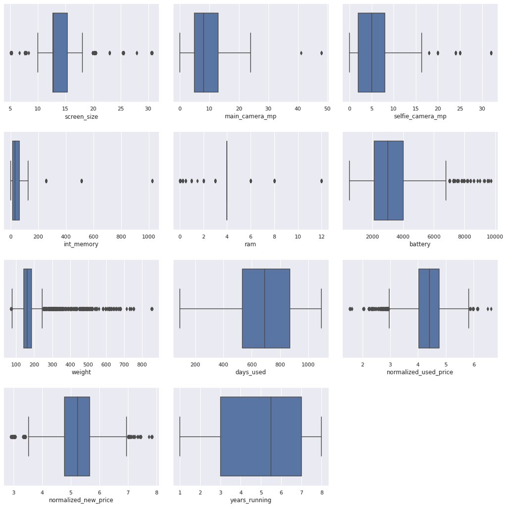

```python
#outliers detection using box plot
num_cols = dfc1.select_dtypes(include=np.number).columns.tolist()

plt.figure(figsize=(15, 15))

for i, variable in enumerate(num_cols):
    plt.subplot(4, 3, i + 1)
    sns.boxplot(data=dfc1, x=variable)
    plt.tight_layout(pad=2)

plt.show()
```

- As observed, there are many outliers in the data.
- However, we will not treat them as they are facts and proper values.

**Data Preparation for Modeling**

```python
#defining X and Y variables
X = dfc1.drop(['normalized_used_price'], axis=1)
y = dfc1['normalized_used_price']

print(X.head())
print('--------------------------------------------------------------------------------------')
print(y.head())
```

```
  brand_name       os  screen_size   4g   5g  main_camera_mp  \
0      Honor  Android        14.50  yes   no            13.0
1      Honor  Android        17.30  yes  yes            13.0
2      Honor  Android        16.69  yes  yes            13.0
3      Honor  Android        25.50  yes  yes            13.0
4      Honor  Android        15.32  yes   no            13.0

   selfie_camera_mp  int_memory  ram  battery  weight  days_used  \
0               5.0        64.0  3.0   3020.0   146.0        127
1              16.0       128.0  8.0   4300.0   213.0        325
2               8.0       128.0  8.0   4200.0   213.0        162
3               8.0        64.0  6.0   7250.0   480.0        345
4               8.0        64.0  3.0   5000.0   185.0        293

   normalized_new_price  years_running
0              4.715100              1
1              5.519018              1
2              5.884631              1
3              5.630961              1
4              4.947837              1
--------------------------------------------------------------------------------------
0    4.307572
1    5.162097
2    5.111084
3    5.135387
4    4.389995
Name: normalized_used_price, dtype: float64
```

```python
#add the intercept to the data
X = sm.add_constant(X)
```

```python
# creating dummy variables
X = pd.get_dummies(
    X,
    columns=X.select_dtypes(include=["object", "category"]).columns.tolist(),
    drop_first=True,
)
X.head()
```

|  | const | screen_size | main_camera_mp | selfie_camera_mp | int_memory | ram | battery | weight | days_used | normalized_new_price | ... | brand_name_Spice | brand_name_Vivo | brand_name_XOLO | brand_name_Xiaomi | brand_name_ZTE | os_Others | os_Windows | os_iOS | 4g_yes | 5g_yes |
| --- | --- | --- | --- | --- | --- | --- | --- | --- | --- | --- | --- | --- | --- | --- | --- | --- | --- | --- | --- | --- | --- |
| 0 | 1.0 | 14.50 | 13.0 | 5.0 | 64.0 | 3.0 | 3020.0 | 146.0 | 127 | 4.715100 | ... | 0 | 0 | 0 | 0 | 0 | 0 | 0 | 0 | 1 | 0 |
| 1 | 1.0 | 17.30 | 13.0 | 16.0 | 128.0 | 8.0 | 4300.0 | 213.0 | 325 | 5.519018 | ... | 0 | 0 | 0 | 0 | 0 | 0 | 0 | 0 | 1 | 1 |
| 2 | 1.0 | 16.69 | 13.0 | 8.0 | 128.0 | 8.0 | 4200.0 | 213.0 | 162 | 5.884631 | ... | 0 | 0 | 0 | 0 | 0 | 0 | 0 | 0 | 1 | 1 |
| 3 | 1.0 | 25.50 | 13.0 | 8.0 | 64.0 | 6.0 | 7250.0 | 480.0 | 345 | 5.630961 | ... | 0 | 0 | 0 | 0 | 0 | 0 | 0 | 0 | 1 | 1 |
| 4 | 1.0 | 15.32 | 13.0 | 8.0 | 64.0 | 3.0 | 5000.0 | 185.0 | 293 | 4.947837 | ... | 0 | 0 | 0 | 0 | 0 | 0 | 0 | 0 | 1 | 0 |

5 rows × 49 columns

```python
#splitting the data in 70:30 ratio for train to test data
x_train, x_test, y_train, y_test = train_test_split(X, y, test_size=0.3, random_state=1)
```

```python
print("Number of rows in train data are", x_train.shape[0])
print("Number of rows in test data are", x_test.shape[0])
```

```
Number of rows in train data are 2417
Number of rows in test data are 1037
```

## Model Building - Linear Regression

```python
olsmodel = sm.OLS(y_train, x_train).fit()
print(olsmodel.summary())
```

```
                              OLS Regression Results
=================================================================================
Dep. Variable:     normalized_used_price   R-squared:                       0.845
Model:                               OLS   Adj. R-squared:                  0.842
Method:                    Least Squares   F-statistic:                     268.7
Date:                   Fri, 23 Sep 2022   Prob (F-statistic):               0.00
Time:                           22:19:46   Log-Likelihood:                 123.85
No. Observations:                   2417   AIC:                            -149.7
Df Residuals:                       2368   BIC:                             134.0
Df Model:                             48
Covariance Type:               nonrobust
=========================================================================================
                            coef    std err          t      P>|t|      [0.025      0.975]
-----------------------------------------------------------------------------------------
const                     1.3156      0.071     18.454      0.000       1.176       1.455
screen_size               0.0244      0.003      7.163      0.000       0.018       0.031
main_camera_mp            0.0208      0.002     13.848      0.000       0.018       0.024
selfie_camera_mp          0.0135      0.001     11.997      0.000       0.011       0.016
int_memory                0.0001   6.97e-05      1.651      0.099   -2.16e-05       0.000
ram                       0.0230      0.005      4.451      0.000       0.013       0.033
battery               -1.689e-05   7.27e-06     -2.321      0.020   -3.12e-05   -2.62e-06
weight                    0.0010      0.000      7.480      0.000       0.001       0.001
days_used              4.216e-05   3.09e-05      1.366      0.172   -1.84e-05       0.000
normalized_new_price      0.4311      0.012     35.147      0.000       0.407       0.455
years_running            -0.0237      0.005     -5.193      0.000      -0.033      -0.015
brand_name_Alcatel        0.0154      0.048      0.323      0.747      -0.078       0.109
brand_name_Apple         -0.0038      0.147     -0.026      0.980      -0.292       0.285
brand_name_Asus           0.0151      0.048      0.314      0.753      -0.079       0.109
brand_name_BlackBerry    -0.0300      0.070     -0.427      0.669      -0.168       0.108
brand_name_Celkon        -0.0468      0.066     -0.707      0.480      -0.177       0.083
brand_name_Coolpad        0.0209      0.073      0.287      0.774      -0.122       0.164
brand_name_Gionee         0.0448      0.058      0.775      0.438      -0.068       0.158
brand_name_Google        -0.0326      0.085     -0.385      0.700      -0.199       0.133
brand_name_HTC           -0.0130      0.048     -0.270      0.787      -0.108       0.081
brand_name_Honor          0.0317      0.049      0.644      0.520      -0.065       0.128
brand_name_Huawei        -0.0020      0.044     -0.046      0.964      -0.089       0.085
brand_name_Infinix        0.1633      0.093      1.752      0.080      -0.019       0.346
brand_name_Karbonn        0.0943      0.067      1.405      0.160      -0.037       0.226
brand_name_LG            -0.0132      0.045     -0.291      0.771      -0.102       0.076
brand_name_Lava           0.0332      0.062      0.533      0.594      -0.089       0.155
```

[output cut: 19 more lines]

```
os_Windows               -0.0207      0.045     -0.459      0.646      -0.109       0.068
os_iOS                   -0.0663      0.146     -0.453      0.651      -0.354       0.221
4g_yes                    0.0528      0.016      3.326      0.001       0.022       0.084
5g_yes                   -0.0714      0.031     -2.268      0.023      -0.133      -0.010
==============================================================================
Omnibus:                      223.612   Durbin-Watson:                   1.910
Prob(Omnibus):                  0.000   Jarque-Bera (JB):              422.275
Skew:                          -0.620   Prob(JB):                     2.01e-92
Kurtosis:                       4.630   Cond. No.                     1.78e+05
==============================================================================

Notes:
[1] Standard Errors assume that the covariance matrix of the errors is correctly specified.
[2] The condition number is large, 1.78e+05. This might indicate that there are
strong multicollinearity or other numerical problems.
```

- Adjusted R-squared is 0.842 which is very good.
- Value of constant coefficient is 1.3156.

## Model Performance Check

```python
# function to compute adjusted R-squared
def adj_r2_score(predictors, targets, predictions):
    r2 = r2_score(targets, predictions)
    n = predictors.shape[0]
    k = predictors.shape[1]
    return 1 - ((1 - r2) * (n - 1) / (n - k - 1))

# function to compute MAPE
def mape_score(targets, predictions):
    return np.mean(np.abs(targets - predictions) / targets) * 100

# function to compute different metrics
def model_performance_regression(model, predictors, target):

    # predicting using the independent variables
    pred = model.predict(predictors)

    r2 = r2_score(target, pred)  #R-squared
    adjr2 = adj_r2_score(predictors, target, pred)  # adjusted R-squared
    rmse = np.sqrt(mean_squared_error(target, pred))  #  RMSE
    mae = mean_absolute_error(target, pred)  # MAE
    mape = mape_score(target, pred)  # MAPE

    # creating a dataframe of metrics
    df_perf = pd.DataFrame(
        {
            "RMSE": rmse,
            "MAE": mae,
            "R-squared": r2,
            "Adj. R-squared": adjr2,
            "MAPE": mape,
        },
        index=[0],
    )

    return df_perf
```

```python
# checking model performance on train set (seen 70% data)
print("Training Performance\n")
olsmodel_train_perf = model_performance_regression(olsmodel,x_train,y_train)
olsmodel_train_perf
```

```
Training Performance
```

|  | RMSE | MAE | R-squared | Adj. R-squared | MAPE |
| --- | --- | --- | --- | --- | --- |
| 0 | 0.229884 | 0.180326 | 0.844886 | 0.841675 | 4.326841 |

```python
# checking model performance on test set (seen 30% data)
print("Test Performance\n")
olsmodel_test_perf = model_performance_regression(olsmodel,x_test,y_test)
olsmodel_test_perf
```

```
Test Performance
```

|  | RMSE | MAE | R-squared | Adj. R-squared | MAPE |
| --- | --- | --- | --- | --- | --- |
| 0 | 0.238358 | 0.184749 | 0.842479 | 0.834659 | 4.501651 |

- The training $R^2$ is 0.84, so the model is not underfitting.
- MAPE of 4.5 on the test data means we can predict 4.5% of the normalized used price.
- The train and test RMSE are comparable, so the model is not overfitting.

## Checking Linear Regression Assumptions

- In order to make statistical inferences from a linear regression model, it is important to ensure that the assumptions of linear regression are satisfied.

**Test for Multicollinearity**

```python
def checking_vif(predictors):
    vif = pd.DataFrame()
    vif["feature"] = predictors.columns

    # calculating VIF for each feature
    vif["VIF"] = [
        variance_inflation_factor(predictors.values, i)
        for i in range(len(predictors.columns))
    ]
    return vif
```

```python
checking_vif(x_train)
```

|  | feature | VIF |
| --- | --- | --- |
| 0 | const | 227.744081 |
| 1 | screen_size | 7.677290 |
| 2 | main_camera_mp | 2.285051 |
| 3 | selfie_camera_mp | 2.812473 |
| 4 | int_memory | 1.364152 |
| 5 | ram | 2.282352 |
| 6 | battery | 4.081780 |
| 7 | weight | 6.396749 |
| 8 | days_used | 2.660269 |
| 9 | normalized_new_price | 3.119430 |
| 10 | years_running | 4.899007 |
| 11 | brand_name_Alcatel | 3.405693 |
| 12 | brand_name_Apple | 13.057668 |
| 13 | brand_name_Asus | 3.332038 |
| 14 | brand_name_BlackBerry | 1.632378 |
| 15 | brand_name_Celkon | 1.774721 |
| 16 | brand_name_Coolpad | 1.468006 |
| 17 | brand_name_Gionee | 1.951272 |
| 18 | brand_name_Google | 1.321778 |
| 19 | brand_name_HTC | 3.410361 |
| 20 | brand_name_Honor | 3.340687 |
| 21 | brand_name_Huawei | 5.983852 |
| 22 | brand_name_Infinix | 1.283955 |
| 23 | brand_name_Karbonn | 1.573702 |
| 24 | brand_name_LG | 4.849832 |
| 25 | brand_name_Lava | 1.711360 |
| 26 | brand_name_Lenovo | 4.558941 |
| 27 | brand_name_Meizu | 2.179607 |
| 28 | brand_name_Micromax | 3.363521 |
| 29 | brand_name_Microsoft | 1.869751 |
| 30 | brand_name_Motorola | 3.274558 |
| 31 | brand_name_Nokia | 3.479849 |
| 32 | brand_name_OnePlus | 1.437034 |
| 33 | brand_name_Oppo | 3.971194 |
| 34 | brand_name_Others | 9.711034 |
| 35 | brand_name_Panasonic | 2.105703 |
| 36 | brand_name_Realme | 1.946812 |
| 37 | brand_name_Samsung | 7.539866 |
| 38 | brand_name_Sony | 2.943161 |
| 39 | brand_name_Spice | 1.688863 |
| 40 | brand_name_Vivo | 3.651437 |
| 41 | brand_name_XOLO | 2.138070 |
| 42 | brand_name_Xiaomi | 3.719689 |
| 43 | brand_name_ZTE | 3.797581 |
| 44 | os_Others | 1.859863 |
| 45 | os_Windows | 1.596034 |
| 46 | os_iOS | 11.784684 |
| 47 | 4g_yes | 2.467681 |
| 48 | 5g_yes | 1.813900 |

- There are 2 columns with high VIF values, indicatin presence of strong multicollinearity.
- We will drop columns with VIF > 5.
- We will ignore the VIF values of dummy variables and constant.

```python
#treating multicollinearity
def treating_multicollinearity(predictors, target, high_vif_columns):

    # empty lists to store adj. R-squared and RMSE values
    adj_r2 = []
    rmse = []

    for cols in high_vif_columns:
        # defining the new train set
        train = predictors.loc[:, ~predictors.columns.str.startswith(cols)]

        # create the model
        olsmodel = sm.OLS(target, train).fit()

        # adding adj. R-squared and RMSE to the lists
        adj_r2.append(olsmodel.rsquared_adj)
        rmse.append(np.sqrt(olsmodel.mse_resid))

    # creating a dataframe for the results
    temp = pd.DataFrame(
        {
            "col": high_vif_columns,
            "Adj. R-squared after_dropping col": adj_r2,
            "RMSE after dropping col": rmse,
        }
    ).sort_values(by="Adj. R-squared after_dropping col", ascending=False)
    temp.reset_index(drop=True, inplace=True)

    return temp
```

```python
#checking R-squared and RMSE

col_list = ['screen_size', 'weight']

res = treating_multicollinearity(x_train, y_train, col_list)
res
```

|  | col | Adj. R-squared after_dropping col | RMSE after dropping col |
| --- | --- | --- | --- |
| 0 | screen_size | 0.838381 | 0.234703 |
| 1 | weight | 0.838071 | 0.234928 |

```python
#dropping screen_size as it makes the least change in adjusted R-squared
col_to_drop = 'screen_size'
x_train2 = x_train.loc[:, ~x_train.columns.str.startswith(col_to_drop)]
x_test2 = x_test.loc[:, ~x_test.columns.str.startswith(col_to_drop)]

# Check VIF now
vif_new = checking_vif(x_train2)
print("VIF after dropping", col_to_drop)
vif_new
```

```
VIF after dropping screen_size
```

|  | feature | VIF |
| --- | --- | --- |
| 0 | const | 202.673906 |
| 1 | main_camera_mp | 2.281835 |
| 2 | selfie_camera_mp | 2.809009 |
| 3 | int_memory | 1.362043 |
| 4 | ram | 2.282350 |
| 5 | battery | 3.842989 |
| 6 | weight | 2.993855 |
| 7 | days_used | 2.648929 |
| 8 | normalized_new_price | 3.077650 |
| 9 | years_running | 4.730315 |
| 10 | brand_name_Alcatel | 3.405533 |
| 11 | brand_name_Apple | 13.000338 |
| 12 | brand_name_Asus | 3.326698 |
| 13 | brand_name_BlackBerry | 1.631042 |
| 14 | brand_name_Celkon | 1.774528 |
| 15 | brand_name_Coolpad | 1.467719 |
| 16 | brand_name_Gionee | 1.941437 |
| 17 | brand_name_Google | 1.319334 |
| 18 | brand_name_HTC | 3.399980 |
| 19 | brand_name_Honor | 3.340354 |
| 20 | brand_name_Huawei | 5.981046 |
| 21 | brand_name_Infinix | 1.283526 |
| 22 | brand_name_Karbonn | 1.573494 |
| 23 | brand_name_LG | 4.832548 |
| 24 | brand_name_Lava | 1.711092 |
| 25 | brand_name_Lenovo | 4.553789 |
| 26 | brand_name_Meizu | 2.176424 |
| 27 | brand_name_Micromax | 3.358629 |
| 28 | brand_name_Microsoft | 1.868243 |
| 29 | brand_name_Motorola | 3.262356 |
| 30 | brand_name_Nokia | 3.464643 |
| 31 | brand_name_OnePlus | 1.437004 |
| 32 | brand_name_Oppo | 3.965445 |
| 33 | brand_name_Others | 9.652572 |
| 34 | brand_name_Panasonic | 2.104853 |
| 35 | brand_name_Realme | 1.943845 |
| 36 | brand_name_Samsung | 7.523421 |
| 37 | brand_name_Sony | 2.937375 |
| 38 | brand_name_Spice | 1.683302 |
| 39 | brand_name_Vivo | 3.650625 |
| 40 | brand_name_XOLO | 2.137844 |
| 41 | brand_name_Xiaomi | 3.713988 |
| 42 | brand_name_ZTE | 3.788971 |
| 43 | os_Others | 1.625212 |
| 44 | os_Windows | 1.595936 |
| 45 | os_iOS | 11.678957 |
| 46 | 4g_yes | 2.466915 |
| 47 | 5g_yes | 1.810289 |

- We have dealth with multicollinearity in the data

```python
olsmod1 = sm.OLS(y_train, x_train2).fit()
print(olsmod1.summary())
```

```
                              OLS Regression Results
=================================================================================
Dep. Variable:     normalized_used_price   R-squared:                       0.842
Model:                               OLS   Adj. R-squared:                  0.838
Method:                    Least Squares   F-statistic:                     267.7
Date:                   Fri, 23 Sep 2022   Prob (F-statistic):               0.00
Time:                           22:19:48   Log-Likelihood:                 97.950
No. Observations:                   2417   AIC:                            -99.90
Df Residuals:                       2369   BIC:                             178.0
Df Model:                             47
Covariance Type:               nonrobust
=========================================================================================
                            coef    std err          t      P>|t|      [0.025      0.975]
-----------------------------------------------------------------------------------------
const                     1.4851      0.068     21.851      0.000       1.352       1.618
main_camera_mp            0.0212      0.002     13.979      0.000       0.018       0.024
selfie_camera_mp          0.0138      0.001     12.128      0.000       0.012       0.016
int_memory             9.551e-05   7.04e-05      1.356      0.175   -4.26e-05       0.000
ram                       0.0229      0.005      4.397      0.000       0.013       0.033
battery               -4.284e-06   7.13e-06     -0.601      0.548   -1.83e-05     9.7e-06
weight                    0.0017   9.22e-05     18.376      0.000       0.002       0.002
days_used              2.773e-05   3.11e-05      0.891      0.373   -3.33e-05    8.88e-05
normalized_new_price      0.4413      0.012     35.841      0.000       0.417       0.465
years_running            -0.0297      0.005     -6.568      0.000      -0.039      -0.021
brand_name_Alcatel        0.0177      0.048      0.368      0.713      -0.077       0.112
brand_name_Apple          0.0660      0.148      0.445      0.656      -0.225       0.357
brand_name_Asus           0.0013      0.048      0.027      0.978      -0.094       0.096
brand_name_BlackBerry    -0.0444      0.071     -0.626      0.531      -0.183       0.095
brand_name_Celkon        -0.0518      0.067     -0.773      0.440      -0.183       0.080
brand_name_Coolpad        0.0136      0.074      0.185      0.854      -0.131       0.158
brand_name_Gionee         0.0154      0.058      0.265      0.791      -0.099       0.130
brand_name_Google        -0.0587      0.085     -0.687      0.492      -0.226       0.109
brand_name_HTC           -0.0321      0.049     -0.660      0.509      -0.127       0.063
brand_name_Honor          0.0352      0.050      0.708      0.479      -0.062       0.133
brand_name_Huawei        -0.0089      0.045     -0.199      0.842      -0.097       0.079
brand_name_Infinix        0.1511      0.094      1.605      0.109      -0.034       0.336
brand_name_Karbonn        0.0998      0.068      1.472      0.141      -0.033       0.233
brand_name_LG            -0.0325      0.046     -0.712      0.476      -0.122       0.057
brand_name_Lava           0.0276      0.063      0.438      0.661      -0.096       0.151
brand_name_Lenovo         0.0345      0.046      0.756      0.450      -0.055       0.124
```

[output cut: 18 more lines]

```
os_Windows               -0.0182      0.046     -0.399      0.690      -0.108       0.071
os_iOS                   -0.1657      0.147     -1.125      0.261      -0.455       0.123
4g_yes                    0.0508      0.016      3.167      0.002       0.019       0.082
5g_yes                   -0.0815      0.032     -2.563      0.010      -0.144      -0.019
==============================================================================
Omnibus:                      234.761   Durbin-Watson:                   1.907
Prob(Omnibus):                  0.000   Jarque-Bera (JB):              440.912
Skew:                          -0.647   Prob(JB):                     1.81e-96
Kurtosis:                       4.644   Cond. No.                     1.78e+05
==============================================================================

Notes:
[1] Standard Errors assume that the covariance matrix of the errors is correctly specified.
[2] The condition number is large, 1.78e+05. This might indicate that there are
strong multicollinearity or other numerical problems.
```

- Let's adjust the p-value to less than 0.05
- Most of the dummy variables with high p-values are not significant to us.
- We will drop one variable at a time since p_value changes after dropping a variable.

**Treating High p-values**

```python
# initial list of columns
predictors = x_train2.copy()
cols = predictors.columns.tolist()

# setting an initial max p-value
max_p_value = 1

while len(cols) > 0:
    # defining the train set
    x_train_aux = predictors[cols]

    # fitting the model
    model = sm.OLS(y_train, x_train_aux).fit()

    # getting the p-values and the maximum p-value
    p_values = model.pvalues
    max_p_value = max(p_values)

    # name of the variable with maximum p-value
    feature_with_p_max = p_values.idxmax()

    if max_p_value > 0.05:
        cols.remove(feature_with_p_max)
    else:
        break

selected_features = cols
print(selected_features)
```

```
['const', 'main_camera_mp', 'selfie_camera_mp', 'ram', 'weight', 'normalized_new_price', 'years_running', 'brand_name_Karbonn', 'brand_name_Samsung', 'brand_name_Sony', 'brand_name_Xiaomi', 'os_Others', 'os_iOS', '4g_yes', '5g_yes']
```

```python
x_train3 = x_train2[selected_features]
x_test3 = x_test2[selected_features]
```

```python
olsmod2 = sm.OLS(y_train, x_train3).fit()
print(olsmod2.summary())
```

```
                              OLS Regression Results
=================================================================================
Dep. Variable:     normalized_used_price   R-squared:                       0.839
Model:                               OLS   Adj. R-squared:                  0.838
Method:                    Least Squares   F-statistic:                     895.7
Date:                   Fri, 23 Sep 2022   Prob (F-statistic):               0.00
Time:                           22:19:48   Log-Likelihood:                 80.645
No. Observations:                   2417   AIC:                            -131.3
Df Residuals:                       2402   BIC:                            -44.44
Df Model:                             14
Covariance Type:               nonrobust
========================================================================================
                           coef    std err          t      P>|t|      [0.025      0.975]
----------------------------------------------------------------------------------------
const                    1.5000      0.048     30.955      0.000       1.405       1.595
main_camera_mp           0.0210      0.001     14.714      0.000       0.018       0.024
selfie_camera_mp         0.0138      0.001     12.858      0.000       0.012       0.016
ram                      0.0207      0.005      4.151      0.000       0.011       0.030
weight                   0.0017      6e-05     27.672      0.000       0.002       0.002
normalized_new_price     0.4415      0.011     39.337      0.000       0.419       0.463
years_running           -0.0292      0.003     -8.589      0.000      -0.036      -0.023
brand_name_Karbonn       0.1156      0.055      2.111      0.035       0.008       0.223
brand_name_Samsung      -0.0374      0.016     -2.270      0.023      -0.070      -0.005
brand_name_Sony         -0.0670      0.030     -2.197      0.028      -0.127      -0.007
brand_name_Xiaomi        0.0801      0.026      3.114      0.002       0.030       0.130
os_Others               -0.1276      0.027     -4.667      0.000      -0.181      -0.074
os_iOS                  -0.0900      0.045     -1.994      0.046      -0.179      -0.002
4g_yes                   0.0502      0.015      3.326      0.001       0.021       0.080
5g_yes                  -0.0673      0.031     -2.194      0.028      -0.127      -0.007
==============================================================================
Omnibus:                      246.183   Durbin-Watson:                   1.902
Prob(Omnibus):                  0.000   Jarque-Bera (JB):              483.879
Skew:                          -0.658   Prob(JB):                    8.45e-106
Kurtosis:                       4.753   Cond. No.                     2.39e+03
==============================================================================

Notes:
[1] Standard Errors assume that the covariance matrix of the errors is correctly specified.
[2] The condition number is large, 2.39e+03. This might indicate that there are
strong multicollinearity or other numerical problems.
```

```python
# checking model performance on train set (seen 70% data)
print("Training Performance\n")
olsmod2_train_perf = model_performance_regression(olsmod2, x_train3, y_train)
olsmod2_train_perf
```

```
Training Performance
```

|  | RMSE | MAE | R-squared | Adj. R-squared | MAPE |
| --- | --- | --- | --- | --- | --- |
| 0 | 0.23403 | 0.182751 | 0.83924 | 0.838235 | 4.395407 |

```python
# checking model performance on test set (seen 30% data)
print("Test Performance\n")
olsmod2_test_perf = model_performance_regression(olsmod2, x_test3, y_test)
olsmod2_test_perf
```

```
Test Performance
```

|  | RMSE | MAE | R-squared | Adj. R-squared | MAPE |
| --- | --- | --- | --- | --- | --- |
| 0 | 0.241434 | 0.186649 | 0.838387 | 0.836013 | 4.556349 |

- No column has p-value greater than 0.05.
- Adjusted R-squared is 0.838 i.e our model can explain 84% of the variance.

**Test for Linearity and Independence**

```python
# let us create a dataframe with actual, fitted and residual values
df_pred = pd.DataFrame()

df_pred["Actual Values"] = y_train  # actual values
df_pred["Fitted Values"] = olsmod2.fittedvalues  # predicted values
df_pred["Residuals"] = olsmod2.resid  # residuals

df_pred.head()
```

|  | Actual Values | Fitted Values | Residuals |
| --- | --- | --- | --- |
| 3026 | 4.087488 | 3.867319 | 0.220169 |
| 1525 | 4.448399 | 4.602001 | -0.153602 |
| 1128 | 4.315353 | 4.286957 | 0.028395 |
| 3003 | 4.282068 | 4.195169 | 0.086899 |
| 2907 | 4.456438 | 4.490563 | -0.034125 |

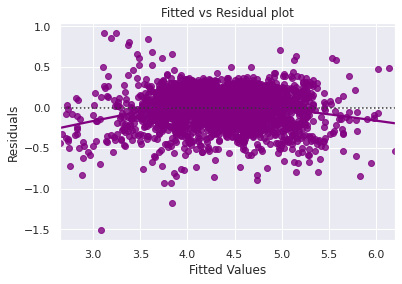

```python
# let's plot the fitted values vs residuals

sns.residplot(
    data=df_pred, x="Fitted Values", y="Residuals", color="purple", lowess=True
)
plt.xlabel("Fitted Values")
plt.ylabel("Residuals")
plt.title("Fitted vs Residual plot")
plt.show()
```

- The scatter plot shows no sign of any pattern, hence the assumptions of linearity and independence are satisfied.

**Test for Normality**

- Error terms, or residuals, should be normally distributed.

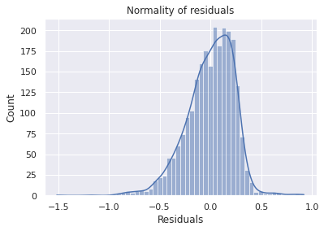

```python
#plotting histogram of residuals
sns.histplot(data=df_pred, x="Residuals", kde=True)
plt.title("Normality of residuals")
plt.show()
```

- The histogram of residuals have a bell shape.

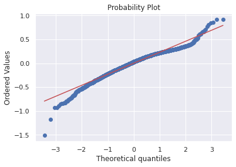

```python
#plotting the Q-Q plot
import pylab
import scipy.stats as stats

stats.probplot(df_pred["Residuals"], dist="norm", plot=pylab)
plt.show()
```

- The residuals follow a straight line except for the tails.

```python
stats.shapiro(df_pred["Residuals"])
```

```
ShapiroResult(statistic=0.9676972031593323, pvalue=6.995328206686811e-23)
```

- Strictly speaking, since the p-value < 0.05, the residuals are not normal.
- However, we can approximate this distribution and accept it as close to being normal. Hence, the assumption is satisfied.

**Test for Homoscedasticity**

- If we get a p-value greater than 0.05, we can say that the residuals are homoscedastic or else they are heteroscedastic.

```python
import statsmodels.stats.api as sms
from statsmodels.compat import lzip

name = ["F statistic", "p-value"]
test = sms.het_goldfeldquandt(df_pred["Residuals"], x_train3)
lzip(name, test)
```

```
[('F statistic', 1.008750419910676), ('p-value', 0.4401970650667301)]
```

- Since the p-value > 0.05, we can say that the residuals are homoscedastic. Hence, the assumption is satisfied.

## Final Model

```python
#creating the final model
x_train_final = x_train3.copy()
x_test_final = x_test3.copy()
```

```python
olsmodel_final = sm.OLS(y_train, x_train_final).fit()
print(olsmodel_final.summary())
```

```
                              OLS Regression Results
=================================================================================
Dep. Variable:     normalized_used_price   R-squared:                       0.839
Model:                               OLS   Adj. R-squared:                  0.838
Method:                    Least Squares   F-statistic:                     895.7
Date:                   Fri, 23 Sep 2022   Prob (F-statistic):               0.00
Time:                           22:19:50   Log-Likelihood:                 80.645
No. Observations:                   2417   AIC:                            -131.3
Df Residuals:                       2402   BIC:                            -44.44
Df Model:                             14
Covariance Type:               nonrobust
========================================================================================
                           coef    std err          t      P>|t|      [0.025      0.975]
----------------------------------------------------------------------------------------
const                    1.5000      0.048     30.955      0.000       1.405       1.595
main_camera_mp           0.0210      0.001     14.714      0.000       0.018       0.024
selfie_camera_mp         0.0138      0.001     12.858      0.000       0.012       0.016
ram                      0.0207      0.005      4.151      0.000       0.011       0.030
weight                   0.0017      6e-05     27.672      0.000       0.002       0.002
normalized_new_price     0.4415      0.011     39.337      0.000       0.419       0.463
years_running           -0.0292      0.003     -8.589      0.000      -0.036      -0.023
brand_name_Karbonn       0.1156      0.055      2.111      0.035       0.008       0.223
brand_name_Samsung      -0.0374      0.016     -2.270      0.023      -0.070      -0.005
brand_name_Sony         -0.0670      0.030     -2.197      0.028      -0.127      -0.007
brand_name_Xiaomi        0.0801      0.026      3.114      0.002       0.030       0.130
os_Others               -0.1276      0.027     -4.667      0.000      -0.181      -0.074
os_iOS                  -0.0900      0.045     -1.994      0.046      -0.179      -0.002
4g_yes                   0.0502      0.015      3.326      0.001       0.021       0.080
5g_yes                  -0.0673      0.031     -2.194      0.028      -0.127      -0.007
==============================================================================
Omnibus:                      246.183   Durbin-Watson:                   1.902
Prob(Omnibus):                  0.000   Jarque-Bera (JB):              483.879
Skew:                          -0.658   Prob(JB):                    8.45e-106
Kurtosis:                       4.753   Cond. No.                     2.39e+03
==============================================================================

Notes:
[1] Standard Errors assume that the covariance matrix of the errors is correctly specified.
[2] The condition number is large, 2.39e+03. This might indicate that there are
strong multicollinearity or other numerical problems.
```

```python
# checking model performance on train set (seen 70% data)
print("Training Performance\n")
olsmodel_final_train_perf = model_performance_regression(
    olsmodel_final, x_train_final, y_train
)
olsmodel_final_train_perf
```

```
Training Performance
```

|  | RMSE | MAE | R-squared | Adj. R-squared | MAPE |
| --- | --- | --- | --- | --- | --- |
| 0 | 0.23403 | 0.182751 | 0.83924 | 0.838235 | 4.395407 |

```python
# checking model performance on test set (seen 30% data)
print("Test Performance\n")
olsmodel_final_test_perf = model_performance_regression(
    olsmodel_final, x_test_final, y_test
)
olsmodel_final_test_perf
```

```
Test Performance
```

|  | RMSE | MAE | R-squared | Adj. R-squared | MAPE |
| --- | --- | --- | --- | --- | --- |
| 0 | 0.241434 | 0.186649 | 0.838387 | 0.836013 | 4.556349 |

- The model is able to explin 84% of the variance in the data.
- RMSE and MAE are low and comparable, so our model is not overfitting.
- MAPE ont he test suggests that we can predict 4.6% of the normalized used price.
- Hence, our model is good.

## Actionable Insights and Recommendations

1) The model is able to explain ~84% of the variation in the data and within 4.6% of the normalized used price on the test data, which is good. This indicates that the model is good for prediction as well as inference purposes.

2) If the main_camera_mp of the devices increases by one unit, then its used price increases by 0.0210 units, all other variables held constant.

3) If the selfie_camera_mp increases by one unit, then its used price increases by 0.0138 units, all other variables held constant.

4) If ram increases by one unit, then its used price increases by 0.0207 units, all other variables held constant.

5) If weight increases by one unit, then its used price increases by 0.0017 units, all other variables held constant.

6) If the number of years running of an device increases by one unit, then its used price decreases by 0.0292 units, all other variables held constant.

7) To compete with other companies in increasing sales, ReCell should provide interesting offers and provide great techincal support.

8) They should promote and advertise their brand more and also highlight their moto to reduce environmental impact.

9) Companies manufacturing phones/tablets sell the new product on EMI, ReCell can also adapt that, making it easy for the customers to buy used phones at affordable rates on EMI.

10) They can conduct surveys and analyse which brand is very popular amongst all, and they can advertise more about the same brand to increase sales.

```python
#converting .ipynb to .html
%%shell
jupyter nbconvert --to html //content/drive/MyDrive/SupervisedLearning/SLF_Project_LearnerNotebook_FullCode.ipynb
```

```
[NbConvertApp] Converting notebook //content/drive/MyDrive/SupervisedLearning/SLF_Project_LearnerNotebook_FullCode.ipynb to html
[NbConvertApp] Writing 403650 bytes to //content/drive/MyDrive/SupervisedLearning/SLF_Project_LearnerNotebook_FullCode.html
```